# Uhlig - 1997

Aishameriane Schmidt

# Bayesian Vector Autoregressions with Stochastic Volatility

(Resumão de (Uhlig 1997))

## Resumo

O trabalho propõe uma metodologia bayesiana para vetores autoregressivos com volatilidade estocástica, onde a evolução da matriz de precisão é dada por uma distribuição beta multivariada.

## Introdução

- A abordagem do autor permite que a matriz de precisão seja não-observável com “choques aleatórios” oriundos de uma distribuição beta multivariada;
- Isso torna possível a interpretação de grandes movimentos abruptos como sendo consequência de uma distribuição com variância aleatória não observável;
- O fato da Wishart e da Beta singulares multivariadas serem conjugadas permite que a integração para a posteriori seja feita de maneira analítica;
- O que leva a generalização das fórmulas para filtro de Kalman padrão para o problema de filtragem não linear proposto
- Ainda assim, as estimativas para os parâmetros autoregressivos requerem métodos numéricos
- O trabalho utiliza amostragem por importância
- Existe um modelo univariado, não bayesiano e não autoregressivo proposto por Shephard (1994) cujo modelo de volatilidade estocástica é um caso particular do Uhlig
- A inovação em comparação com outros trabalhos é que o método do Uhlig resultou em fórmulas exatas para atualização da posteriori, uma vez que a integração sobre os choques aleatórios sobre as matrizes de precisão está em forma analítica;

## Caso simples

Considere o seguinte modelo:

$$\begin{equation}\tag{1}
y_t = \beta y_{t-1} + h_t^{-\frac{1}{2}}\varepsilon_t \quad \text{com } \epsilon_t \sim \mathcal{N}(0,1)
\end{equation}$$
$$\begin{equation}\tag{2}
h_{t+1} = h_t \frac{\vartheta_t}{\lambda} \quad \text{com } \vartheta_t \sim \mathcal{B}_1(\frac{\nu+1}{2},\frac{1}{2})
\end{equation}$$

Onde:

- Todos os $\vartheta_t$ ’s e $\epsilon_t$ ’s são independentes;
- $t=1, \ldots, T$ é o tempo;
- $y_t \in \mathbb{R}$ são dados observáveis;
- $\lambda > 0$ e $\nu > 0$ são parâmetros;
- $\mathcal{B}_1(p,q)$ é a distribuição Beta univariada no intervalo $[0,1]$.

A equação (2) especifica que a precisão não observada $h_t$ do termo $h_t^{\frac{1}{2}}\varepsilon_t$ de (1) é estocástica, de forma que o modelo consegue capturar hererocedasticidade autocorrelacionada (comum em séries temporais financeiras).

A abordagem bayesiana para analisar (1) e (2) irá requerer uma priori $\pi_T(\beta, h_1)$ para $\beta$ e $h_1$, dado $y_0$, com o objetivo de podermos encontrar a distribuição posterior $\pi_T(\beta, h_{T+1})$ dado os dados $y_0, \ldots, y_T$.

Então. fixando $\lambda, \nu > 0$ e escolhendo $\bar{b}_0 \in \mathbb{R}$, $n_0, s_0^2 > 0$ e uma função $g_0(\beta)$ para descrever a densidade a priori:

$$\begin{equation}\tag{3}
\pi_0(\beta, h_1) \propto g_0(\beta) f_{NG}(\beta, h_1 | \bar{b}_0, \lambda n_0, s_0, \nu)
\end{equation}$$

Onde $f_{NG}$ denota a densidade da Normal-Gama, dada por:

$$\begin{equation}\tag{3.1}
f_{NG}(\beta, h_1 | \bar{b}_0, \lambda n_0, s_0, \nu) = \frac{\lambda n_0^{\frac{1}{2}}(\frac{\nu s_0}{2})^{\frac{\nu}{2}}}{(2\pi)^\frac{1}{2}\Gamma(\frac{\nu}{2})} h_1^{\frac{\nu-1}{2}}\exp \left\{-\frac{1}{2}(\beta + \bar{b}_0)^2 \lambda n_0 h_1 - \frac{\nu}{2} s_0 h_1 \right\}
\end{equation}$$

Para esta distribuição, a precisão $h_1$ segue uma distribuição $\mathcal{G}(s_0, \nu)$ e, condicional a $h$, $\beta$ segue uma distribuição $\mathcal{N}(\bar{b}_0, (\lambda n_0 h_1)^{-1})$.

A forma da priori permite um tratamento mais flexível próximo da raiz unitária através da função $g_0(\beta)$.

Este modelo simples resulta nas seguintes equações:

$$\begin{equation}\tag{4}
n_t = \lambda n_{t-1} + y_{t-1}^2
\end{equation}$$
$$\begin{equation}\tag{5}
\bar{b}_t = \frac{\lambda \bar{b}_{t-1}n_{t-1} + y_t y_{t-1}}{n_t}
\end{equation}$$
$$\begin{equation}\tag{6}
s_t = \lambda s_{t-1} + \frac{\lambda}{\nu} e_t^2\left(\frac{1-y_{t-1}^2}{n_t}\right) \quad \text{onde } e_t = y_t - \bar{b}_{t-1}y_{t-1}
\end{equation}$$

E

$$\begin{equation}\tag{7}
g_t(\beta) = g_{t-1}(\beta)\left((\beta - \bar{b}_t)^2 n_t + \frac{\nu}{\lambda}s_t \right)^{-\frac{1}{2}}
\end{equation}$$

Para $t = 1, \ldots, T$. Isto nos dá a seguinte posteriori:

$$\begin{equation}\tag{7.1}
\pi_T(\beta, h_{T+1}) \propto g_T(\beta) f_{NG}(\beta, h_{T+1}| \bar{\beta}_T, \lambda n_T, s_T, \nu).
\end{equation}$$

Das equações acima, temos:

- As equações (4) e (5) são as fórmulas recursivas ou as equações do filtro de Kalman para MQG;
- As observações são ponderadas de acordo com o valor de $s_t$ pela equação (7);
- A equação (6) mostra como obter $s_t$ para $h_{t+1}$ (note que em (3) temo $h_1$ e $s_0$) basicamente usando um lag geométrico nos resíduos passados.

O trabalho de Shephard introduz equações com a versão clássica de (1) e (2) sem o termo autoregressico $\beta y_{t-1}$ Aisha: Tá, mas aí o $y_t$ é tipo um passeio aleatório, que não depende do passado a não ser via $h$?. Para incluir a parte autoregressiva, ele sugere utilizar uma forma aproximada para as fórmulas do filtro. O que o trabalho do Uhlig traz de novo são essas fórmulas em uma forma exata, embora ainda sejam calculadas aproximações para estimativa de $\beta$. No Shephard também não é abordado o caso multivariado.

Observe que para $\lambda = \frac{\nu}{(\nu+1)}$, temos que o termo $\frac{\lambda}{\nu}$ em (6) pode ser reescrito como:

$$\begin{align*}
\frac{\lambda}{\nu} &= \\
&= \frac{\frac{\nu}{(\nu+1)}}{\nu} \\
&= \frac{\nu}{(\nu+1)}\frac{1}{\nu} \\
&= \frac{1}{(\nu+1)}\\
&= \frac{1+\nu-\nu}{(\nu+1)}\\
&= \frac{\nu + 1}{\nu + 1} - \frac{\nu}{(\nu+1)}\\
&= 1 - \frac{\nu}{(\nu+1)}\\
&= 1-\lambda
\end{align*}$$

Aisha: Mas e o que isso significa?

Para $\lambda = \frac{\nu+1}{\nu+2}$ temos que a equação (6) pode ser reescrita como:

$$\begin{align*}
s_t = \frac{\nu+1}{\nu+2} s_{t-1} + \frac{\frac{\nu+1}{\nu+2}}{\nu} e_t^2\left(\frac{1-y_{t-1}^2}{n_t}\right)
\end{align*}$$

Substituindo na densidade de $h_t$, que é uma Gama com parâmetros $s_t$ e $\nu$, teremos:

$$\begin{align*}
p(h|st,\nu) &= \frac{h^{\nu-1}}{\Gamma(\nu)s_t^\nu}\exp\left\{-\frac{h}{s_t} \right\}\\
&= \frac{h^{\nu-1}}{\Gamma(\nu)\left(\frac{\nu+1}{\nu+2} s_{t-1} + \frac{\frac{\nu+1}{\nu+2}}{\nu} e_t^2\left(\frac{1-y_{t-1}^2}{n_t}\right) \right)^\nu} \exp\left\{-\frac{h}{\frac{\nu+1}{\nu+2} s_{t-1} + \frac{\frac{\nu+1}{\nu+2}}{\nu} e_t^2\left(\frac{1-y_{t-1}^2}{n_t}\right)}\right\}
\end{align*}$$

E teremos que $\mathbb{E}[h_{t+1}|h_t] = h_t$, isto é, $h_t$ é um martingale (pois sua expectância será exatamente igual ao valor da variável no tempo anterior). Aisha: Não consegui ver como que da expressão acima vamos ter que a média condicional vai dar isso… Teria que usar que $\mathbb{E}[h_{t+1}|h_t] = \int h f_{h_t|h_{t+1}}(h_t, h_{t+1})dh_t$ ?

Aisha: No início da página 62 ele começa a falar que quando $\nu \to \infty$, vamos ter $h_1 = s_0^{-1}$. Eu tentei fazer o limite da equação (6) e aí temos que $s_1 = \lambda s_0$. Só que aí não consegui relacionar com $h_1$. Tentei usar que $h_1 = h_0 \frac{\vartheta_0}{\lambda}$ e substituir o $\vartheta$ pela densidade da $Beta((\nu+1)/2, 1/2)$, mas ficou uma coisa estranha. É isso mesmo?

Aisha: Coisas que eu tentei fazer para ajustar o gráfico:

- Mudar de pbeta para dbeta
- Multiplicar ao invés de dividir lambda
- Mudar os parâmetros da beta de lugar
- Mudar o $\vartheta$ começando em 0 ou em 0.001
- Mudar valores de $\nu$
- Calcular a densidade da beta avaliada em $\lambda / \vartheta$, mas aí tem valores maiores que 1 e o trem se perde
- Colocar a densidade da beta “na mão”
- Usar a densidade da beta não padrão (Zellner, pág 373) para usar $\lambda / \vartheta$ como v.a. (o que não parece fazer sentido olhando a equação (2))
- Apagar tudo e começar de novo?

Aisha: Coisas que eu ainda não tentei:

- Colocar fogo
- Rubber duck debugging

### Rascunho

Da equação (2), temos:

$$\begin{align*}
h_{t+1} = h_t \frac{\vartheta_t}{\lambda} \qquad \text{com } \vartheta_t \sim \mathcal{B}\left(\frac{\nu+1}{2}, \frac{1}{2} \right)
\end{align*}$$

Calculando essa equação para $h_t$, teremos:

$$\begin{align*}
h_{t} &= h_{t-1} \frac{\vartheta_t}{\lambda}
\end{align*}$$

Agora, substituindo o termo em (1) que é $h_t^{-\frac{1}{2}}$, vamos ter:

$$\begin{align*}
h_{t}^{-\frac{1}{2}} &= \left(h_{t-1} \frac{\vartheta_t}{\lambda}\right)^{-\frac{1}{2}}\\
&= \left(h_{t-1} \right)^{-\frac{1}{2}} \left(\frac{\vartheta_t}{\lambda}\right)^{-\frac{1}{2}}\\
&= \left(h_{t-1} \right)^{-\frac{1}{2}} \left(\frac{\lambda}{\vartheta_t}\right)^{\frac{1}{2}}\\
& = \left(h_{t-1} \right)^{-\frac{1}{2}} \left(\frac{\frac{\nu}{\nu+1}}{\vartheta_t}\right)^{\frac{1}{2}}\\
& = \left(h_{t-1} \right)^{-\frac{1}{2}} \left(\frac{\nu}{\nu+1}\frac{1}{\vartheta_t}\right)^{\frac{1}{2}}
\end{align*}$$

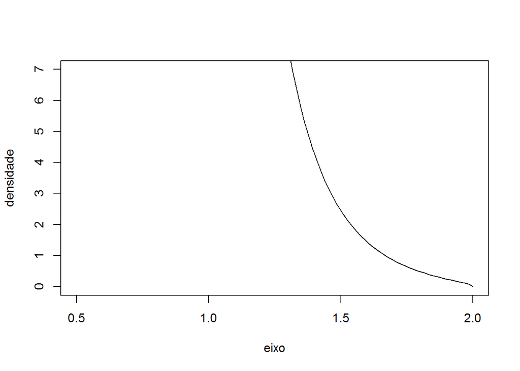

```r
nu = c(1,2,5,7,10)
eixo<-seq(0.5, 2,length.out = 100)
vartheta<-seq(0.01,1,length.out = 100)

lambda = nu[5]/(nu[5]+1)
densidade<- lambda/dbeta(vartheta, shape1 = (nu[5]+1)/2, shape2=1/2)
plot(eixo, densidade, type='l', ylim=c(0,7), xlim = c(0.5, 2))
```

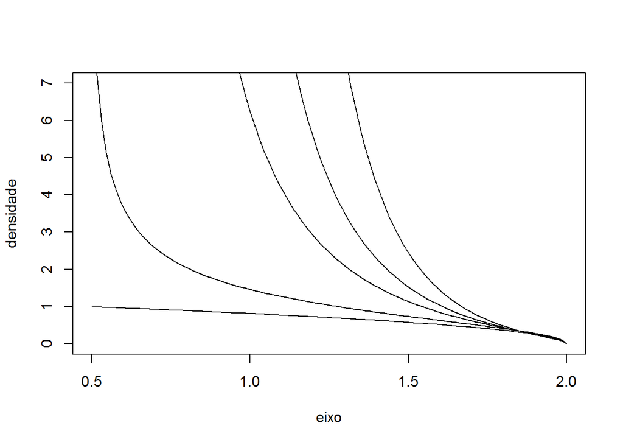

```r
for (i in 1:length(nu)) {
  lambda = nu[i]/(nu[i]+1)
  densidade<- lambda/dbeta(vartheta, shape1 = (nu[i]+1)/2, shape2=1/2)
  if (i == 1) {
    plot(eixo, densidade, type='l', ylim=c(0,7), xlim = c(0.5, 2))
  } else {
    lines(eixo, densidade)
  }
}
```

## Caso geral

O artigo considera um modelo $Var(k)$ com matriz de precisão dos erros variante no tempo:

$$\begin{equation}\tag{08}
Y_t = B_{(0)}C_t + B_{(1)}Y_{t-1}+ B_{(2)}Y_{t-2} + \ldots + B_{(k)}Y_{(t-k)} + \mathcal{U}(H_t^{-1})'\epsilon_t \qquad \text{com } \epsilon \sim \mathcal{N}(0, I_m)
\end{equation}$$
$$\begin{equation}\tag{09}
H_{(t+1)} = \frac{\mathscr{U}(H_t)'\Theta_t\mathscr{U}(H_t)}{\lambda} \qquad \text{com} \Theta \sim \mathcal{B}(\frac{\nu+c+km}{2}, \frac{1}{2})
\end{equation}$$

Onde:

- $t=1, \ldots, T$ denota o tempo;
- $Y_t, \ t=1-k, \ldots, T$ é um vetor de tamanho $m \times 1$ que contém as variáveis observadas;
- $C_t$ é um vetor de tamanho $c \times 1$ que contém os regressores determinísticos tais como a constante e a tendência ao longo do tempo;
- A matriz de coeficientes $B_{(0)}$ tem tamanho $m \times c$;
- As matrizes de coeficientes $B_{(i)}$, $i= 1, \ldots, k$ são de tamanho $m \times m$;
- $\nu > m-1$ e $\lambda > 0$ são parâmetros;
- $\epsilon_t$, $t = 1, \ldots, T$ tem tamanho $m \times 1$;
- $\Theta_t$, $t = 1, \ldots, T$ são independentes; São identicamente distribuídas tb?
- $\mathscr{U}(H)$ é a decomposição de Cholesky (superior) da matriz $H$, que é positiva definida;
- $\mathcal{B}(p,q)$ é a distribuição beta multivariada.

### Conjugação da Beta e da Whishart

#### Wishart

(retirado de (Muirhead 2005))

**Definição W1:** Seja $A=Z'Z$, onde $Z$ é uma matriz $n \times m$ com distribuição $\mathcal{N}(0, I_n \otimes Sigma)$, então dizemos que $A$ segue uma distribuição **Wishart** com $n$ graus de liberdade e matriz de covariância $\Sigma$ e denotamos $A \sim \mathcal{W}_m(n, \Sigma)$, onde o subscrito $m$ indica o tamanho da matriz $A$ (então as distribuições normais tem $n$ amostras aleatórias de tamanho $m$?)

#### Produto de Kronecker

**Observação:** $\otimes$ é o *produto de Kronecker para matrizes*.

**Definição K1:** Seja $A = (a_{i,j})$ uma matriz $p \times q$ e $B = (b_{m,n})$ uma matriz de tamanho $r \times s$. O produto de Kronecker de $A$ e $B$, denotado por $A \otimes B$, será a matriz de tamanho $pr \times qs$ dada por:

$$\begin{align*}
A \otimes B =
\begin{bmatrix}
a_{11}B & a_{12}B & \ldots & a_{1q}B\\
a_{21}B & a_{22}B & \ldots & a_{2q}B\\
\vdots & \vdots & \ddots & \vdots \\
a_{p1}B & a_{p2}B & \ldots & a_{pq}B
\end{bmatrix}
\end{align*}$$

Este produto também é chamado de *produto direto*.

O resultado que usamos na Wishart é o seguinte: Se $\Sigma$ é uma matriz $k \times k$ (não precisa ser quadrada, mas no nosso caso é), então a matriz bloco diagonal $nk \times nk$ com $\Sigma$ sendo repetida $n$ vezes na diagonal é $I_n \otimes \Sigma$, isto é:

$$\begin{align*}
I_n \otimes \Sigma =
\begin{bmatrix}
\Sigma & 0 & \ldots & 0\\
0 & \Sigma & \ldots & 0\\
\vdots & \vdots & \ddots & \vdots \\
0 & 0 & \ldots & \Sigma
\end{bmatrix}
\end{align*}$$

#### Beta

##### Caso univariado

Dá para fazer uma correspondência entre o univariado e o multivariado ou nada a ver?

(retirado de (Zellner 1996))

Dizemos que uma variável aleatória $x$ segue uma distribuição beta se a sua densidade é dada por:

$$\begin{equation}\tag{B1}
p(x|a,b,c) = \frac{1}{c B(a,b)}\left(\frac{x}{c} \right)^{a-1}\left(1-\frac{x}{c} \right)^{b-1} \qquad 0 \leq x \leq c
\end{equation}$$

Onde:

- $a, b, c > 0$ são parâmetros;
- $B(a,b)$ é a função beta dada por: $B(a,b) = \frac{\Gamma(a)\Gamma(b)}{\Gamma(a+b)}$, com $0 < a, b < -\infty$

Podemos fazer uma mudança de variável usando $y = \frac{x}{c}$ para obter a forma padrão da densidade beta, dada por:

$$\begin{equation}\tag{B1}
p(y|a,b,c) = \frac{1}{B(a,b)}\left(y \right)^{a-1}\left(1-y \right)^{b-1} \qquad 0 \leq x \leq 1
\end{equation}$$

##### Caso multivariado

**Teorema B1** (teorema 3.3.1 de (Muirhead 2005)) Sejam $A$ e $B$ independentes onde $A \sim \mathcal{W}_m(n_1, \Sigma)$ e $B \sim \mathcal{W}_m(n_2, \Sigma)$, com $n_1 > m-1, n_2 > m-1$. Considere $A+B = T'T$, onde $T$ é uma matriz diagonal superior de tamanho $m \times m$ com elementos positivos na sua diagonal. Seja $U$ a matriz simétrica de tamanho $m \times m$ definida por $A = T'UT$. Então, $A + B$ e $U$ são independentes; $A+B \sim \mathcal{W}_m(n_1 + n_2, \Sigma)$ e $U$ tem densidade dada por:

$$\begin{equation}\tag{B2}
\frac{\Gamma_m \left[\frac{1}{2}(n_1 + n_2) \right]}{\Gamma_m \left(\frac{1}{2}n_1\right)\Gamma_m \left(\frac{1}{2}n_2\right)} (det U)^{\frac{n_1 - m -1}{2}}det(I_m- U)^{\frac{n_2 - m -1}{2}} \quad (0 < U < I_m)
\end{equation}$$

Onde $(0 < U < I_m)$ significa que $U$ e $I_m - U$ são ambas positivas definidas.

Uma matriz $U$ como no teorema acima é dita seguir uma *distribuição beta multivariada* com parâmetros $\frac{1}{2}n_1$ e $\frac{1}{2}n_2$. A notação será $U \sim \mathcal{B}_m(\frac{1}{2}n_1,\frac{1}{2}n_2)$.

##### Gerando valores de uma Beta Multivariada

Queremos gerar retiradas aleatórias de uma distribuição Beta Multivariada, denotada por $\mathcal{B}_m(\frac{1}{2}n_1,\frac{1}{2}n_2)$. Para isso, iremos utilizar a densidade da Wishart já implementada no R.

Usando o teorema (B1), vamos gerar $A$ e $B$ independentes com a [função `rWishart()`](https://stat.ethz.ch/R-manual/R-devel/library/stats/html/rWishart.html).

###### Uma única matriz

```r
# rWishart(n, df, Sigma) generates n random matrices, distributed according
# to te Wishart distribution with parameters Sigma and df.

# For the first matrix
# Set the degrees of freedom
df1<-10

# Set the covariance matrix
# The diag(n) creates the nxn identity matrix
sigma_1 <- diag(4)

# Creates the Wishart first matrix
A<-rWishart(1, df1, sigma_1)
A<-matrix(A, nrow=nrow(sigma_1))

# For the second matrix
# Set the degrees of freedom
df2<-5

# Set the covariance matrix
# The diag(n) creates the nxn identity matrix
sigma_2 <- diag(4)

# Creates the Wishart first matrix
B<-rWishart(1, df2, sigma_2)
B<-matrix(B, nrow=nrow(sigma_2))

# Sums A and B
C<-A+B

# The chol() function gives T, an upper-triangular mxm matrix with positive diagonal elements
T<-chol(C)

# We now calculate U = T'^{-1}AT^{-1}
U <- solve(t(T))%*%A%*%solve(T)
U
```

```
##            [,1]        [,2]        [,3]       [,4]
## [1,]  0.4949567  0.08765970 -0.24736296 -0.0526553
## [2,]  0.0876597  0.64037300  0.06724819 -0.3248431
## [3,] -0.2473630  0.06724819  0.59573078  0.0892727
## [4,] -0.0526553 -0.32484306  0.08927270  0.3233369
```

###### Caso geral

```r
# rWishart(n, df, Sigma) generates n random matrices, distributed according
# to te Wishart distribution with parameters Sigma and df.

# Set the number of matrices (samples)
n<-2

# For the first matrix
# Set the degrees of freedom
df1<-10

# Set the covariance matrix
# The diag(n) creates the nxn identity matrix
sigma_1 <- diag(4)

# Creates the Wishart first matrix
A<-rWishart(n, df1, sigma_1)

# For the second matrix
# Set the degrees of freedom
df2<-5

# Set the covariance matrix
# The diag(n) creates the nxn identity matrix
sigma_2 <- diag(4)

# Creates the Wishart first matrix
B<-rWishart(n, df2, sigma_2)

# Sums A and B
C<-A+B

# The chol() function gives T, an upper-triangular mxm matrix with positive diagonal elements
# Creates the T array with the same dimension of C
T<-C

# Populates T
for (i in 1:n) {
  T[,,i]<-chol(C[,,i])
}

# We now calculate U = T'^{-1}AT^{-1}
#Creates U
U<-T

for (i in 1:n) {
  U[,,i] <- solve(t(T[,,i]))%*%A[,,i]%*%solve(T[,,i])
}

U
```

```
## , , 1
##
##             [,1]        [,2]        [,3]        [,4]
## [1,]  0.43642049 -0.10786110 -0.03759439  0.04192132
## [2,] -0.10786110  0.65026096  0.26348511 -0.04861759
## [3,] -0.03759439  0.26348511  0.68017258  0.08944575
## [4,]  0.04192132 -0.04861759  0.08944575  0.66536244
##
## , , 2
##
##              [,1]        [,2]         [,3]        [,4]
## [1,]  0.734994385  0.07936254 -0.001632227 -0.07442593
## [2,]  0.079362543  0.73484820 -0.144202760  0.13536653
## [3,] -0.001632227 -0.14420276  0.542908718  0.22506157
## [4,] -0.074425933  0.13536653  0.225061569  0.85245298
```

# Referências

Muirhead, Robb John. 2005. *Aspects of Multivariate Statistical Theory*. Wiley-Interscience.

Uhlig, Harald. 1997. “Bayesian Vector Autoregressions with Stochastic Volatility.” *Econometrica* 65 (1): 59. doi:10.2307/2171813.

Zellner, Arnold. 1996. *An Introduction to Bayesian Inference in Econometrics*. A Wiley-Interscience Publication, John Wiley & Sons, Inc.